# Database Querying via SELECT

36-350 – Statistical Computing

Week 13 – Spring 2019

# SELECT

The `SELECT` command is how we query a database. It is a versatile and powerful command!

A shortened definition that highlights elements of the syntax that are important in the context of this class is:

```
SELECT
  [*]
  [<expression>]
  [FROM <expression>]
  [WHERE <condition>]
  [GROUP BY <expression>]
  [HAVING <condition>]
  [ORDER BY <expression>];
```

As we explain these options (`FROM` and `WHERE` this week, the rest next time), keep the following in mind:

- You can pass functions into `SELECT`. (See below.)
- `SELECT` constructs virtual tables, and its displayed output is a table. (Everything is a table in `Postgres` and in `SQL` in general.)

  ```
  SELECT pi();
  ```

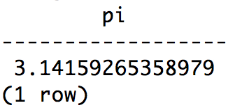

# SELECT

More to keep in mind:

- The functions you pass to `SELECT` can generate vectors, which populate columns in the virtual table(s) it constructs:

  ```
  SELECT 2*x as evens FROM generate_series(1,2) as x;
  ```

  Be at one with the parser! `Postgres` will scan this command and parse it, and will generate tables. Here:
- `generate_series(1,2)` will be run first, and it will construct a virtual table with an column named `x` (the `as` sets the column name) and two entries: 1 and 2.
- then, another table will be constructed based on the first one, with one column named `evens` and entries 2 and 4. This final table is what will be displayed as output.

# SELECT

- One can nest calls to `SELECT`:

  ```
  SELECT min(r) as minimum, avg(r) as mean, max(r) as maximum FROM
    (SELECT random() as r FROM generate_series(1,10000)) as _;
  ```

  This generates an unnamed (see the “_“) virtual table of 10000 draws from a Uniform(0,1) distribution, from which the minimum, average, and maximum values are selected. The final table has one entry for each of three columns.

# WHERE

We can select the rows to view or act on by giving logical conditions in a `WHERE` clause:

```
SELECT r FROM (SELECT random() as r FROM generate_series(1,10000)) as _
  WHERE r > 0.98 and r < 0.99;
SELECT * FROM (SELECT random() as r, random() as s FROM generate_series(1,10000)) as _
  WHERE r > 0.99 or s < 0.01;
SELECT id from (SELECT generate_series(1,101) as id) as _
  WHERE id = 50;
SELECT id from
  (SELECT generate_series(1,10) as id,
   ('{A,B,C}'::text[])[ceil(random()*3)] as letter) as _
  WHERE letter = 'C';
```

In the second example, we output all columns (in this case, `r` and `s`) via the use of “*“.

The fourth example is a bit more complex: by using `generate_series()`, we can generate a particular number of rows (and not just 1), and in each row, a letter A, B, or C is selected at random. The letters are cast to a text array type, `3*random()` generates random numbers from 0 to 3, and `ceil()` rounds the random numbers up to the next integer (meaning 1, 2, or 3). If 1 is selected, then the letter A is sampled, etc. Finally, we determine which rows had the letter C.